# NOLA-SIS results from particle tracking

Kristina Øie Kvile, NIVA

21 mars 2022

# Introduction

## Aims

For a northern Norwegian case study site, use high-resolution particle-tracking modeling to study the seasonality of river outflow and residence time of river water in the fjord to understand the role of seasonality and high flow events for fjord biogeochemistry and land-ocean fluxes.

# Methods

## Study area

The study area encompasses the mouth of the Målselv river in Northern Norway and the downstream Malangen fjord that can transport river water out into the Norwegian Sea (Figur 1). We released particles in a band at the river mouth of the Målselv river, i.e. at the transition from ~5 meter to deeper water. The study area was divided into four boxes at varying distance from the river mouth to study the flux of river water and residence time.

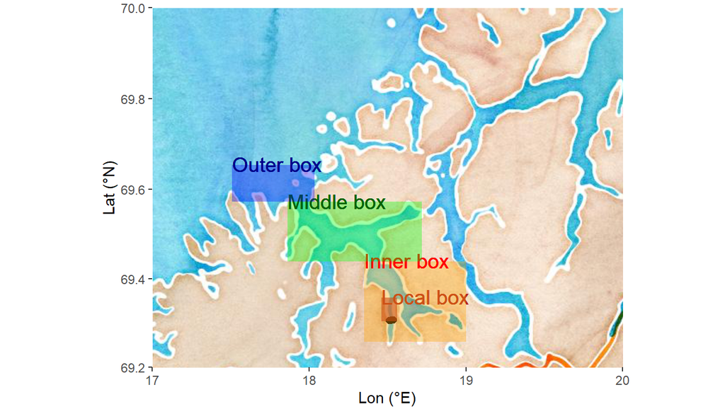

Figur 1: Study area. The black points show the particle release area at the mouth of the Målselv river. The colored boxes show the limits of areas used to describe the flow of river water in time and residence time of water.

## Number of particles released

As a first trial, this is done for 2018, but the same will be repeated for 2019, 2020 and 2021.

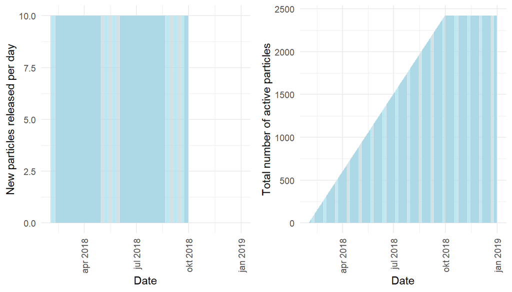

Figur 2: Number of particles released per day and cumulative number of particles in run.

# Results

Cumulatively over the course of the year (February to December), the river water is distributed thorughout the study area, with highest densities over time in some local areas along the coast in the inner Malangen fjord, in addition to the release area (where all river water passes through initially, Figur 3).

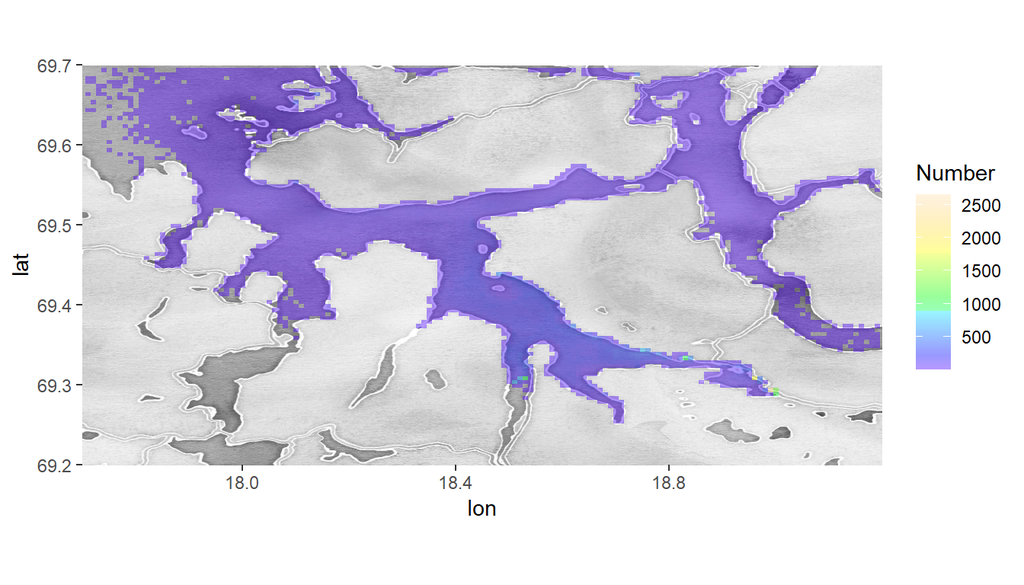

Figur 3: Cumulative distribution of particles during the simulation (counting all particles that have passed through a grid cell).

Figur 4 shows the distribution of particles at the first day of each month of the simulation.

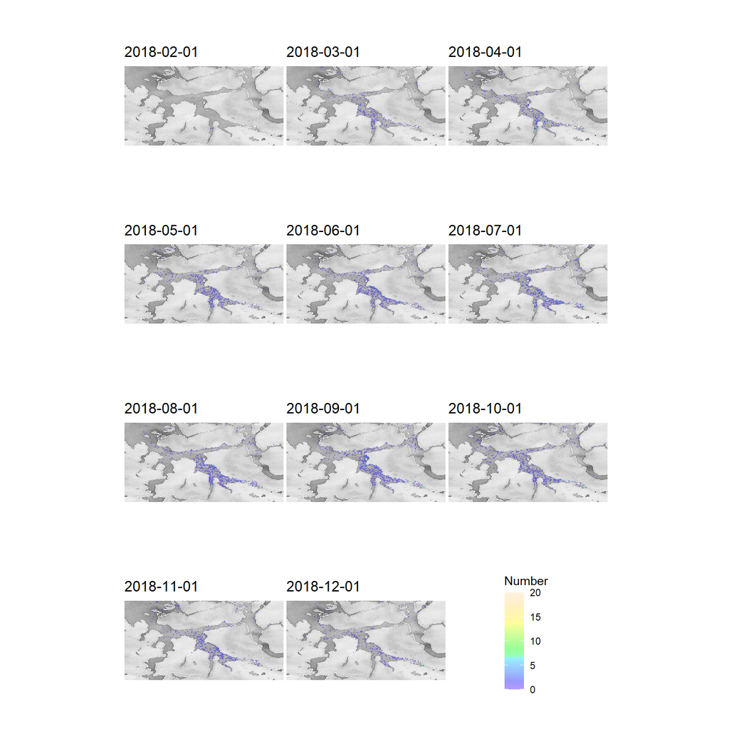

Figur 4: Distribution of particles in the study area at the first day of each month during the simulation.

Figur 5 shows the number of particles present within each per box (Figur 1) per day during the simulation.

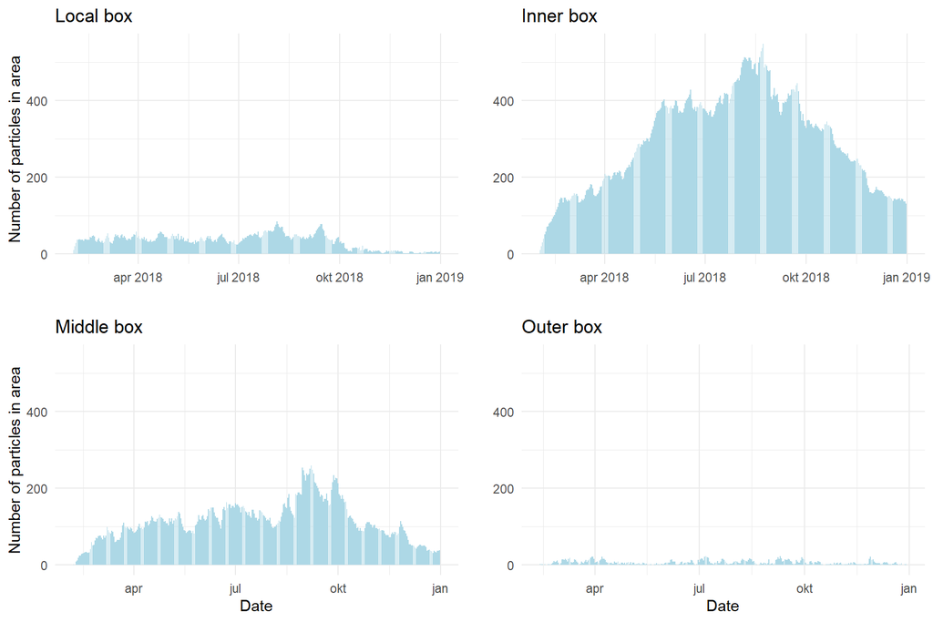

Figur 5: Number of particles present within each subregion of the study area per day during the simulation.